# Project 1

### NHL stats API

`stats` function is created to connect to NHL stats API. a logic argument `is.numeric`is used to return single or full records. A input number will call a single record with corresponding `id`. Any no number , for example `teams` (in following example) will read the full data. Note that here full data is actually a group of datasets.

```r
stats <- function(id, ... ) {
  base_url2 <- "https://statsapi.web.nhl.com/api/v1/teams/"
  if (is.numeric (id)) {
    apiurl <- paste0 (base_url2, id, "/?expand=team.stats")
  }
  if (!is.numeric (id)) {
    apiurl<- paste0 (base_url2, "?expand=team.stats")
    }
  team <- GET (apiurl)
  team_txt <- content (team,"text", encoding="UTF-8")
  stats_json <- fromJSON(team_txt, flatten=TRUE)
  team_df <- data.frame(stats_json)
  return(team_df)
}
stats_data <- stats (2)
stats_data
```

```
##                                                                                                                                                                            copyright
## 1 NHL and the NHL Shield are registered trademarks of the National Hockey League. NHL and NHL team marks are the property of the NHL and its teams. © NHL 2021. All Rights Reserved.
##   teams.id         teams.name      teams.link teams.abbreviation
## 1        2 New York Islanders /api/v1/teams/2                NYI
##   teams.teamName teams.locationName teams.firstYearOfPlay
## 1      Islanders           New York                  1972
##                                                                                                                                                                                                                                                                                                          …
## 1 56, NA, 32, 12th, 17, 11th, 7, 11th, 71, 12th, 63.4, 12th, 2.714, 21st, 2.232, 2nd, 1.2418, 7th, 18.8, 20th, 27, 24th, 22, 2nd, 144, 28th, 83.7, 6th, 28.9821, 22nd, 28.3929, 10th, 0.821, 10th, 0.321, 16th, 0.833, 7th, 0.842, 20th, 0.69, 4th, 0.44, 4th, 2916, 31st, 1498, 25th, 1418, 2nd, 51.4, 9…
##   teams.shortName            teams.officialSiteUrl teams.franchiseId
## 1    NY Islanders http://www.newyorkislanders.com/                22
##   teams.active                  teams.venue.name    teams.venue.link
## 1         TRUE Nassau Veterans Memorial Coliseum /api/v1/venues/null
##   teams.venue.city teams.venue.timeZone.id teams.venue.timeZone.offset
## 1        Uniondale        America/New_York                          -4
##   teams.venue.timeZone.tz teams.division.id teams.division.name
## 1                     EDT                25     MassMutual East
##    teams.division.link teams.conference.id teams.conference.name
## 1 /api/v1/divisions/25                   6               Eastern
##   teams.conference.link teams.franchise.franchiseId
## 1 /api/v1/conferences/6                          22
##   teams.franchise.teamName  teams.franchise.link
## 1                Islanders /api/v1/franchises/22
```

```r
stats_data2 <- stats ("teams")
head(stats_data2)
```

```
##                                                                                                                                                                            copyright
## 1 NHL and the NHL Shield are registered trademarks of the National Hockey League. NHL and NHL team marks are the property of the NHL and its teams. © NHL 2021. All Rights Reserved.
## 2 NHL and the NHL Shield are registered trademarks of the National Hockey League. NHL and NHL team marks are the property of the NHL and its teams. © NHL 2021. All Rights Reserved.
## 3 NHL and the NHL Shield are registered trademarks of the National Hockey League. NHL and NHL team marks are the property of the NHL and its teams. © NHL 2021. All Rights Reserved.
## 4 NHL and the NHL Shield are registered trademarks of the National Hockey League. NHL and NHL team marks are the property of the NHL and its teams. © NHL 2021. All Rights Reserved.
## 5 NHL and the NHL Shield are registered trademarks of the National Hockey League. NHL and NHL team marks are the property of the NHL and its teams. © NHL 2021. All Rights Reserved.
## 6 NHL and the NHL Shield are registered trademarks of the National Hockey League. NHL and NHL team marks are the property of the NHL and its teams. © NHL 2021. All Rights Reserved.
##   teams.id          teams.name      teams.link teams.abbreviation
## 1        1   New Jersey Devils /api/v1/teams/1                NJD
## 2        2  New York Islanders /api/v1/teams/2                NYI
## 3        3    New York Rangers /api/v1/teams/3                NYR
## 4        4 Philadelphia Flyers /api/v1/teams/4                PHI
## 5        5 Pittsburgh Penguins /api/v1/teams/5                PIT
## 6        6       Boston Bruins /api/v1/teams/6                BOS
##   teams.teamName teams.locationName teams.firstYearOfPlay
```

[output cut: 62 more lines]

### wrapper function

A wrapper function is constructed in order to control the access to any of above endpoints. The functions will be called via if/else statements by inputting different modifiers. As mentioned above, `id` or its combination with `name` will return single record or full data (when `id` is `0` . Three examples are shown below

```r
wrapper <- function (modifier,id,name,...) {
  if (modifier == "franchise") {
    franchise_Data <- franchise (id,name)
    franchise_Data
  }
    else if (modifier == "total"){
     total_Data <- total (id,name)
     total_Data
    }
      else if (modifier == "season") {
       season_Data <- season(id)
       season_Data
      }
        else if (modifier == "goalie"){
         goalie_Data <- goalie (id)
         goalie_Data
        }
          else if (modifier == "skater"){
            skater_Data <- skater (id)
            skater_Data
          }
            else if (modifier == "detail") {
              detail_Data <-  detail (id)
              detail_Data
            }
              else if (modifier == "stats"){
                stas_Data <- stats (id)
                stas_Data
              }
}
result1 <- wrapper ("franchise", 2, "Montreal Wanderers")
result1
```

```
##   data.id data.firstSeasonId      data.fullName data.lastSeasonId
## 1       2           19171918 Montreal Wanderers          19171918
##   data.mostRecentTeamId data.teamAbbrev data.teamCommonName
## 1                    41             MWN           Wanderers
##   data.teamPlaceName total
## 1           Montreal    39
```

```r
result2 <- wrapper ("skater", 0)
str(result2)
```

```
## 'data.frame':    17209 obs. of  32 variables:
##  $ data.id                         : int  16888 16889 16890 16891 16892 16893 16894 16895 16896 16897 ...
##  $ data.activePlayer               : logi  FALSE FALSE FALSE FALSE FALSE FALSE ...
##  $ data.assists                    : int  417 0 794 712 1111 33 13 852 142 0 ...
##  $ data.firstName                  : chr  "George" "Billy" "Johnny" "Jean" ...
##  $ data.franchiseId                : int  5 2 6 1 6 9 9 16 23 2 ...
##  $ data.franchiseName              : chr  "Toronto Maple Leafs" "Montreal Wanderers" "Boston Bruins" "Montréal Canadiens" ...
##  $ data.gameTypeId                 : int  2 2 2 2 2 2 2 2 2 2 ...
##  $ data.gamesPlayed                : int  1188 2 1436 1125 1518 216 216 1144 1283 4 ...
##  $ data.goals                      : int  296 1 545 507 395 60 24 358 36 0 ...
##  $ data.lastName                   : chr  "Armstrong" "Bell" "Bucyk" "Beliveau" ...
##  $ data.mostAssistsGameDates       : chr  "1956-01-07, 1957-03-16, 1957-11-24, 1961-01-15, 1961-12-02, 1962-02-25, 1964-02-23, 1965-12-18, 1969-01-31" "1917-12-19, 1917-12-29" "1971-01-01" "1955-02-19, 1956-12-01, 1962-11-24, 1965-11-20, 1967-12-28" ...
##  $ data.mostAssistsOneGame         : int  3 0 5 4 5 2 1 5 3 0 ...
##  $ data.mostAssistsOneSeason       : int  35 0 65 58 73 17 4 89 16 0 ...
##  $ data.mostAssistsSeasonIds       : chr  "19651966" "19171918" "19701971" "19601961" ...
```

[output cut: 18 more lines]

```r
result3 <- wrapper ("stats", 2)
result3
```

```
##                                                                                                                                                                            copyright
## 1 NHL and the NHL Shield are registered trademarks of the National Hockey League. NHL and NHL team marks are the property of the NHL and its teams. © NHL 2021. All Rights Reserved.
##   teams.id         teams.name      teams.link teams.abbreviation
## 1        2 New York Islanders /api/v1/teams/2                NYI
##   teams.teamName teams.locationName teams.firstYearOfPlay
## 1      Islanders           New York                  1972
##                                                                                                                                                                                                                                                                                                          …
## 1 56, NA, 32, 12th, 17, 11th, 7, 11th, 71, 12th, 63.4, 12th, 2.714, 21st, 2.232, 2nd, 1.2418, 7th, 18.8, 20th, 27, 24th, 22, 2nd, 144, 28th, 83.7, 6th, 28.9821, 22nd, 28.3929, 10th, 0.821, 10th, 0.321, 16th, 0.833, 7th, 0.842, 20th, 0.69, 4th, 0.44, 4th, 2916, 31st, 1498, 25th, 1418, 2nd, 51.4, 9…
##   teams.shortName            teams.officialSiteUrl teams.franchiseId
## 1    NY Islanders http://www.newyorkislanders.com/                22
##   teams.active                  teams.venue.name    teams.venue.link
## 1         TRUE Nassau Veterans Memorial Coliseum /api/v1/venues/null
##   teams.venue.city teams.venue.timeZone.id teams.venue.timeZone.offset
## 1        Uniondale        America/New_York                          -4
##   teams.venue.timeZone.tz teams.division.id teams.division.name
## 1                     EDT                25     MassMutual East
##    teams.division.link teams.conference.id teams.conference.name
## 1 /api/v1/divisions/25                   6               Eastern
##   teams.conference.link teams.franchise.franchiseId
## 1 /api/v1/conferences/6                          22
##   teams.franchise.teamName  teams.franchise.link
## 1                Islanders /api/v1/franchises/22
```

## Exploratory Data analysis

Next applications of above constructed functions will be elaborated via several examples.

Below are examples of reading data using wrapper functions from three different ends API end points and combine them using inner_join function twice. Note that three whole datasets are obtained through `franchise`, `total` and `season` function in order to compare different franchise teams.

```r
franchise_Data <- wrapper ("franchise",0, "full")
#rename data.id with data.franchiseId so that franchise dataset can be combined with other datasets.
franchise_Data <- rename(franchise_Data, data.franchiseId = data.id  )

total_Data <- wrapper ("total",0,"full" )

season_Data <-wrapper ("season",0 )

#first join via inner_join function based on identical variables of "data.franchiseId".
frch_seas_comb <- inner_join(franchise_Data, season_Data [ ,-1], copy=TRUE, by=("data.franchiseId"))

#second join.
frch_seas_ttl_comb <- inner_join (frch_seas_comb, total_Data [ ,-1], copy=TRUE, by=("data.franchiseId"))
```

### New variables

Shown below are three newly generated variables. data.win_pct denotes the ratio of data.homewins to the data.gamePlayed which can reflect the success rates of teams. data.mgoal_level classified mostgoals into several levels , which is convenient for summary. Similarily, data.hwin_level divide data.homewins into five classes, which is favorable for comparison of different teams. Finally, above three new variants are all included into dataset which is renamed as `frch_seas_ttl_comb`.

```r
data.win_pct=round(frch_seas_ttl_comb$data.homeWins/
                     frch_seas_ttl_comb$data.gamesPlayed,2)

data.mgoal_level <- cut(frch_seas_ttl_comb$data.mostGoals,
                        breaks=c(0,120,200,300,400),
                        labels=c("low","low-mid","high-mid","high"))

data.hwin_level <- cut(frch_seas_ttl_comb$data.homeWins,
                       breaks=c(0, 100, 300, 500,  1000, 2500 ),
                       labels=c("0-100","100-300","300-500","500-1000", "1000-2500"))

frch_seas_ttl_comb <-mutate(frch_seas_ttl_comb,data.win_pct,
                            data.mgoal_level,data.hwin_level)
```

### contingency tables

```r
tab1 <-table(frch_seas_ttl_comb$data.franchiseName,
             frch_seas_ttl_comb$data.gameTypeId )
head(tab1)
```

```
##
##                      2 3
##   Anaheim Ducks      1 1
##   Arizona Coyotes    3 3
##   Boston Bruins      1 1
##   Brooklyn Americans 2 1
##   Buffalo Sabres     1 1
##   Calgary Flames     2 2
```

```r
tab2 <- table(frch_seas_ttl_comb$data.franchiseName,
              frch_seas_ttl_comb$data.mgoal_level  )
head(tab2)
```

```
##
##                      low low-mid high-mid high
##   Anaheim Ducks        0       0        2    0
##   Arizona Coyotes      0       0        0    6
##   Boston Bruins        0       0        0    2
##   Brooklyn Americans   0       3        0    0
##   Buffalo Sabres       0       0        0    2
##   Calgary Flames       0       0        0    4
```

```r
tab3 <- table(frch_seas_ttl_comb$data.gameTypeId,
             frch_seas_ttl_comb$data.hwin_level)
head(tab3)
```

```
##
##     0-100 100-300 300-500 500-1000 1000-2500
##   2    17       8       9       12        11
##   3    34       9       0        0         0
```

```r
tab4 <- table(frch_seas_ttl_comb$data.franchiseName,
              frch_seas_ttl_comb$data.hwin_level,
              frch_seas_ttl_comb$data.gameTypeId  )
head(tab4)
```

```
## , ,  = 2
##
##
##                      0-100 100-300 300-500 500-1000 1000-2500
##   Anaheim Ducks          0       0       0        1         0
##   Arizona Coyotes        0       1       2        0         0
##   Boston Bruins          0       0       0        0         1
##   Brooklyn Americans     1       1       0        0         0
##   Buffalo Sabres         0       0       0        0         1
##   Calgary Flames         0       1       0        1         0
##
## , ,  = 3
##
##
##                      0-100 100-300 300-500 500-1000 1000-2500
##   Anaheim Ducks          1       0       0        0         0
##   Arizona Coyotes        3       0       0        0         0
##   Boston Bruins          0       1       0        0         0
##   Brooklyn Americans     1       0       0        0         0
##   Buffalo Sabres         1       0       0        0         0
##   Calgary Flames         2       0       0        0         0
```

### numerical summary

```r
hwin_sum <- frch_seas_ttl_comb %>%  group_by( data.franchiseName)  %>%
 summarise(min=min(data.homeWins),avg=mean(data.homeWins),med=median(data.homeWins),max=(data.homeWins), sd=sd(data.homeWins))
head(hwin_sum)
```

```
## # A tibble: 6 x 6
## # Groups:   data.franchiseName [2]
##   data.franchiseName   min   avg   med   max    sd
##   <chr>              <int> <dbl> <dbl> <int> <dbl>
## 1 Anaheim Ducks         51  304    304    51  358.
## 2 Anaheim Ducks         51  304    304   557  358.
## 3 Arizona Coyotes        3  131.    64   340  155.
## 4 Arizona Coyotes        3  131.    64    10  155.
## 5 Arizona Coyotes        3  131.    64   307  155.
## 6 Arizona Coyotes        3  131.    64    12  155.
```

```r
hloss_sum <- frch_seas_ttl_comb %>%  group_by( data.franchiseName)  %>%
 summarise(min=min(data.homeLosses),avg=mean(data.homeLosses),med=median(data.homeLosses),max=(data.homeLosses), sd=sd(data.homeLosses))
head(hloss_sum)
```

```
## # A tibble: 6 x 6
## # Groups:   data.franchiseName [2]
##   data.franchiseName   min   avg   med   max    sd
##   <chr>              <int> <dbl> <dbl> <int> <dbl>
## 1 Anaheim Ducks         34  196. 196.     34  230.
## 2 Anaheim Ducks         34  196. 196.    359  230.
## 3 Arizona Coyotes        1  113.  69.5   249  123.
## 4 Arizona Coyotes        1  113.  69.5    19  123.
## 5 Arizona Coyotes        1  113.  69.5   274  123.
## 6 Arizona Coyotes        1  113.  69.5    16  123.
```

```r
win_pct_sum <- frch_seas_ttl_comb %>%  group_by( data.franchiseName)  %>% summarise(min=min(data.win_pct),avg=mean(data.win_pct),med=median(data.win_pct),max=(data.win_pct), sd=sd(data.win_pct))
head(win_pct_sum)
```

```
## # A tibble: 6 x 6
## # Groups:   data.franchiseName [2]
##   data.franchiseName   min   avg   med   max     sd
##   <chr>              <dbl> <dbl> <dbl> <dbl>  <dbl>
## 1 Anaheim Ducks       0.26 0.285 0.285  0.31 0.0354
## 2 Anaheim Ducks       0.26 0.285 0.285  0.26 0.0354
## 3 Arizona Coyotes     0.18 0.233 0.225  0.25 0.0539
## 4 Arizona Coyotes     0.18 0.233 0.225  0.18 0.0539
## 5 Arizona Coyotes     0.18 0.233 0.225  0.23 0.0539
## 6 Arizona Coyotes     0.18 0.233 0.225  0.19 0.0539
```

### Five plots

Five plots are used to disclose some typical data.

#### bar plot

Data of data.homewins levels obtained via aforementioned functions are plotted using`ggplot()` and `geom_bar()`.The first argument of `ggplot()` is the dataset name, the second use `Aesthetic(Aes)` to introduce a variable as x axis which is then mapped to `geom_bar()` The first bar graph compares total counts of different data.homewin levels where the lowest levels has the highest counts. The second introduces an additional variable, data.gameTypeid to stress the effect of different game type. While the counts of type 2 are distributed at all levels, those of type 3 focus on the lowest two levels.

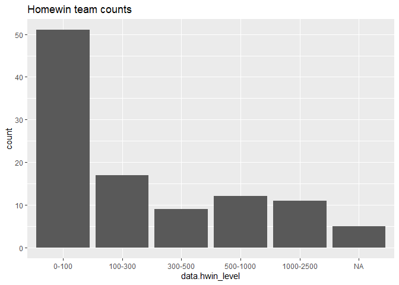

```r
g1 <- ggplot(frch_seas_ttl_comb, aes (x=data.hwin_level))
g1+ geom_bar() + ggtitle("Homewin team counts")
```

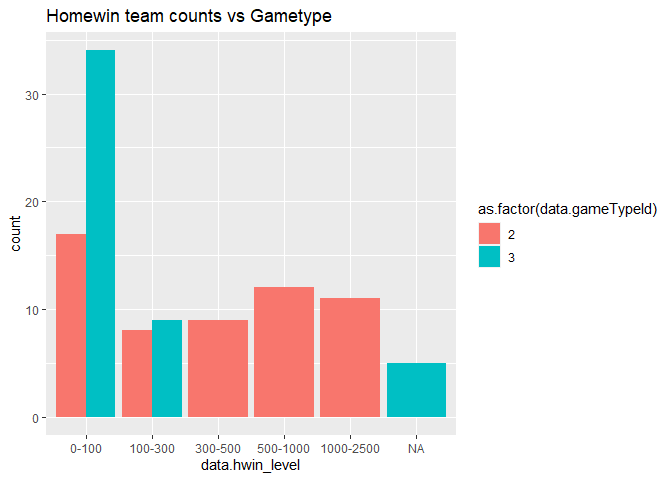

```r
g2 <- ggplot(frch_seas_ttl_comb, aes (
  x=data.hwin_level, fill=as.factor(data.gameTypeId)))
g2 + geom_bar(position="dodge") +
  ggtitle("Homewin team counts vs Gametype")
```

#### histogram

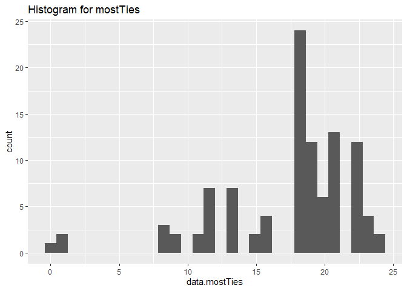

```r
g3 <- ggplot(frch_seas_ttl_comb, aes(x=data.mostTies))
g3+ geom_histogram(bins=30) + ggtitle("Histogram for mostTies" )
```

#### box plot

A box plot is produced by apply `ggplot()` and `geom_boxplot` to resulted data using above function. Note that as data.gameTypeId is *numeric*, it needs to be converted to *character*using `as.factor`function. It can be seen that gameType2 has much higher value than gameType3. In addition, 3the latter has some outliers.

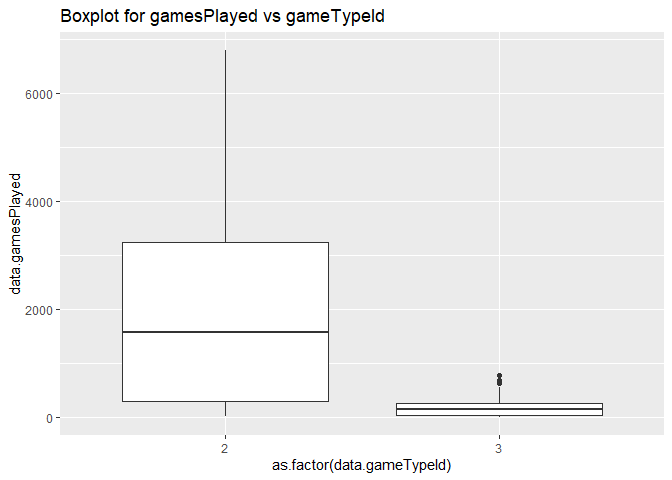

```r
g4 <- ggplot (frch_seas_ttl_comb, aes(x=as.factor(data.gameTypeId),
                                      y=data.gamesPlayed))
g4 + geom_boxplot() + ggtitle("Boxplot for gamesPlayed vs gameTypeId ")
```

#### scatter plot

Lastly, a scatter graph is generated by plotting `data.homeLosses` against `data.homeWins`. An additional variable, `data.gameTypeId`is used to group data. For grouping, `data.gameTypeId`is converted to categorical variable. `geom_point()` is combined with `ggplot()` together. `geom()` with the argument of `method=lm` return a regression line. The scatter plot display linear relationship between `data.homeWins`and `data.homeLosses`.

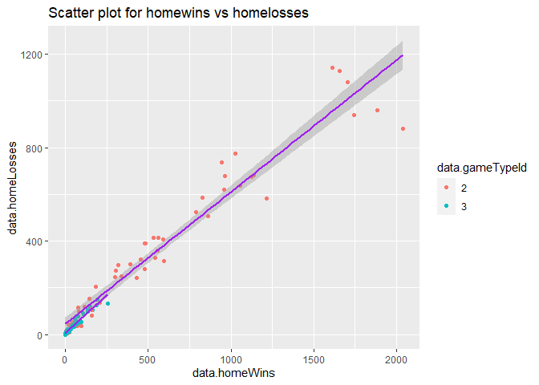

```r
frch_seas_ttl_comb$data.gameTypeId <-
  as.factor(frch_seas_ttl_comb$data.gameTypeId)
g5 <- ggplot (frch_seas_ttl_comb, aes( x=data.homeWins,
               y=data.homeLosses, group= data.gameTypeId))
g5 + geom_point (aes(color= data.gameTypeId))+
  geom_smooth(method=lm, color="purple") +
  ggtitle ("Scatter plot for homewins vs homelosses")
```

As a conclusion, above functions can conveniently call data from different API endpoints and generate nice tables and graphs.